# Assignment on Probability

### Index

I Basic Probability.II. Conditional Probability. III.Bayes Theorem

### Basic probability

**1. Two dies are rolled at once. Find out the probability for sum of numbers being even and one of the die shows 6.** **Analysis:** It is single event, the total no of possible combinations are : 36 ( as there are two dice) Total no of favourable outcomes = (sum is even and one of the die should show 6) possible combinations are : (6,2) (6,4),(6,6),(2,6),(4,6) **Answer:** probability = (No of favourable outcomes / Total no of possible outcomes) = (5/36)

**2. Two dies are rolled at once. Find out the probability for sum of numbers being less than 7.** **Analysis:** No of favourable outcomes are : (1,5)(1,4),(1,3),(1,2),(1,1) ,(2,4),(2,3),(2,2),(2,1),(3,3),(3,2),(3,1),(4,2),(4,1),(5,1) **Answer:** probability = (No of favourable outcomes / Total no of possible outcomes) = (15/36)

**3. You toss a fair coin three times :Given that you have observed atleast one heads , what is the probability that you observe atleast two heads?** **Analysis:** Total possible outcomes = 7, as it was observed that , ateast one head No of favouraable outcomes = 4,( which had atleast two heads)(THH)(HTH)(HHT)(HHH) **Answer:** p(atleastTwoHeads) = 4/7

**4. A and B are a married couple with two kids. One of them is a girl. What is the probability that their other kid is also a girl?** **Analysis:** The second kid probability is not dependent on first kid, so it is normal probability **Answer:** p(girl) = 1/2

Top^

### Conditional, Joint and Marginal Probability

**5. In my town, it's rainy for one third of the days. Given that it is rainy, there will be heavy traffic with probability 1/2, and given that it is not rainy, there will be heavy traffic with probability 1/4. If it's rainy and there is heavy traffic, I arrive late for work with probability 1/2. On the other hand, the probability of being late is 1/8 if it is not rainy and there is no heavy traffic. In other situations (rainy and no traffic, not rainy and traffic) the probability of being late is 0.25, 0.25. You pick a random day.**

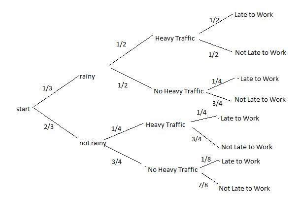

**a) What is the probability that it's not raining and there is heavy traffic and I am not late?** **Analysis:** p(NotRaining ^ HeavyTraffic ^ Not Late) = p(NotLate|(HeavyTraffic & Not rainy)) X p(HeavyTraffic|not rainy) X p(not rainy) **Answer:** p(NotRaining ^ HeavyTraffic ^ Not Late) = (3/4) X (1/4) X (2/3) = (1/8) **b) What is the probability that I am late?** **Analysis:** p(Late) = p(Late| (HT & Rainy)) + p(Late| (NHT & Rainy) + p(Late| (HT & Not Rainy)) + p(NHT & Not Rainy) **Answer:** p(Late) = (1/2 X 1/2 X 1/3) + (1/4 X 1/2 X 1/3) + (1/4 X 1/4 X 2/3) + (1/8 X 3/4 X 2/3) = 11/48 **c) Given that I arrived late at work, what is the probability that it rained that day?** **Analysis:** p(rainy|Late) =p(Late|rainy) X p(Late) / p(rainy) = [p(Late|(HT&rainy)) + p(Late|(NHT & rainy))] X p(Late) / p(rainy) **Answer:** p(rainy|Late) = [(1/2 X 1/2) + (1/4 X 1/2)] X 11/48 /(1/3) = 33/128

**6. A box contains three coins: two regular coins and one fake two-headed coin (P(Heads)=1), You pick a coin at random and toss it.**

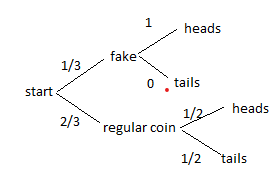

**6a) What is the probability that it lands heads up?** **Analysis: and Answer:** p(Heads) = p(H|fake)X p(fake) +p(H|regular) X p(regular) = (1 X 1/3) + (1/2 X 2/3) = 2/3

**6b) You pick a coin at random and toss it and get heads. What is the probability that it is the two-headed coin?** **Analysis: and Answer:** p(Heads) = 2/3 ( from previous question) p(fake|Heads) = p(Heads|fake) X p(fake) / p(Heads) = (1 X 1/3) / (2/3)= 1/2

**7. Suppose that, of all the customers at a coffee shop** * 70% purchase a cup of coffee * 40% purchase a piece of cake * 20% purchase both a cup of coffee and a piece of cake. **Given that a randomly chosen customer has purchased a piece of cake, what is the probability that he/she also purchased a cup of coffee.**

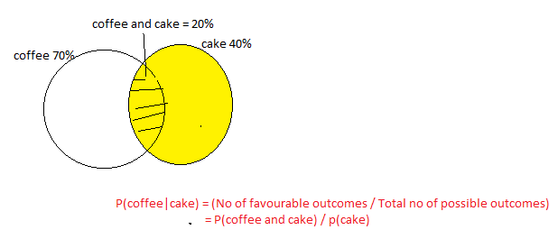

**Analysis: and Answer:** p(coffee) = 0.7 , p(cake) = 0.4, p(coffe and cake) = 0.2 p(coffee|cake) = p(coffe and cake) / p(cake) = 0.2 / 0.4 = 0.5

**8. A is known to tell the truth in 5 cases out of 6 and he states that a white ball was drawn from a bag containing 8 blacks and 1 white ball. Find the probability that the white ball was drawn.**

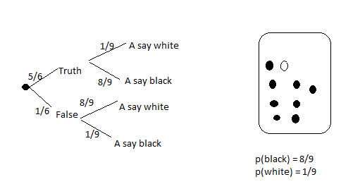

**Analysis: and Answer:** p(Truth|white) = p(white|Truth) X p(Truth) / p(white) p(white) = p(white|Truth) X p(Truth) + p(white|False) X p(False) = (1/9 X 5/6) + (8/9 X 1/6) = 13 /54 p(Truth|white) = (1/9 X 5/6) / (13/54) = 5/13

**9 A speaks the truth 4 out of 5 times. A die is tossed. A report that it is a 6. What are the chances that there actually was a 6?**

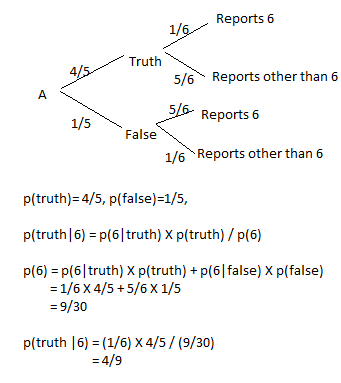

**Analysis: and Answer:** p(truth)= 4/5, p(false)=1/5, p(truth|6) = p(6|truth) X p(truth) / p(6) = 4/9

**10. In a class, 40% of the student’s study math and science. 60% of the student’s study math. What is the probability of a student studying science given he/she is already studying math?** **Analysis: and Answer:** p(Maths and Science) = 0.4, p(Maths) = 0.6 P(science|Maths) = p( Maths and Science) / p(Maths) = 0.4/0.6 = 2/3

Top^

### Bayes Theorem

**12. You need to figure out whether a company is fraud based on the legal charges they filed. We have the knowledge that, the chances a company submitting fraudulent fillings is 0.1. There exists an algorithm that can predict fraud. This algorithm returns a correct positive result in 92% of the cases in which the fraud is present and correct negative results in 90% of the cases where the fraud is not present. Suppose we observe a company for whom the algorithm test returns a fraud result. Calculate the posterior probability that this company truly did fraud in their filings.**